## Note: This is a sample solution for the project. Projects will NOT be graded on the basis of how well the submission matches this sample solution. Projects will be graded on the basis of the rubric only.

# **Problem Statement**

#### **Business Context**

Understanding customer personality and behavior is pivotal for businesses to enhance customer satisfaction and increase revenue. Segmentation based on a customer's personality, demographics, and purchasing behavior allows companies to create tailored marketing campaigns, improve customer retention, and optimize product offerings.

A leading retail company with a rapidly growing customer base seeks to gain deeper insights into their customers' profiles. The company recognizes that understanding customer personalities, lifestyles, and purchasing habits can unlock significant opportunities for personalizing marketing strategies and creating loyalty programs. These insights can help address critical business challenges, such as improving the effectiveness of marketing campaigns, identifying high-value customer groups, and fostering long-term relationships with customers.

With the competition intensifying in the retail space, moving away from generic strategies to more targeted and personalized approaches is essential for sustaining a competitive edge.

#### **Objective**

In an effort to optimize marketing efficiency and enhance customer experience, the company has embarked on a mission to identify distinct customer segments. By understanding the characteristics, preferences, and behaviors of each group, the company aims to:

1. Develop personalized marketing campaigns to increase conversion rates.
2. Create effective retention strategies for high-value customers.
3. Optimize resource allocation, such as inventory management, pricing strategies, and store layouts.

As a data scientist tasked with this project, your responsibility is to analyze the given customer data, apply machine learning techniques to segment the customer base, and provide actionable insights into the characteristics of each segment.

#### **Data Dictionary**

The dataset includes historical data on customer demographics, personality traits, and purchasing behaviors. Key attributes are:

1. **Customer Information**
   - **ID:** Unique identifier for each customer.
   - **Year_Birth:** Customer's year of birth.
   - **Education:** Education level of the customer.
   - **Marital_Status:** Marital status of the customer.
   - **Income:** Yearly household income (in dollars).
   - **Kidhome:** Number of children in the household.
   - **Teenhome:** Number of teenagers in the household.
   - **Dt_Customer:** Date when the customer enrolled with the company.
   - **Recency:** Number of days since the customer’s last purchase.
   - **Complain:** Whether the customer complained in the last 2 years (1 for yes, 0 for no).
2. **Spending Information (Last 2 Years)**
   - **MntWines:** Amount spent on wine.
   - **MntFruits:** Amount spent on fruits.
   - **MntMeatProducts:** Amount spent on meat.
   - **MntFishProducts:** Amount spent on fish.
   - **MntSweetProducts:** Amount spent on sweets.
   - **MntGoldProds:** Amount spent on gold products.
3. **Purchase and Campaign Interaction**
   - **NumDealsPurchases:** Number of purchases made using a discount.
   - **AcceptedCmp1:** Response to the 1st campaign (1 for yes, 0 for no).
   - **AcceptedCmp2:** Response to the 2nd campaign (1 for yes, 0 for no).
   - **AcceptedCmp3:** Response to the 3rd campaign (1 for yes, 0 for no).
   - **AcceptedCmp4:** Response to the 4th campaign (1 for yes, 0 for no).
   - **AcceptedCmp5:** Response to the 5th campaign (1 for yes, 0 for no).
   - **Response:** Response to the last campaign (1 for yes, 0 for no).
4. **Shopping Behavior**
   - **NumWebPurchases:** Number of purchases made through the company’s website.
   - **NumCatalogPurchases:** Number of purchases made using catalogs.
   - **NumStorePurchases:** Number of purchases made directly in stores.
   - **NumWebVisitsMonth:** Number of visits to the company’s website in the last month.

# **Let's start coding!**

## **Importing necessary libraries**

```python
# Libraries to help with reading and manipulating data
import pandas as pd
import numpy as np

# libaries to help with data visualization
import matplotlib.pyplot as plt
import seaborn as sns

# Removes the limit for the number of displayed columns
pd.set_option("display.max_columns", None)
# Sets the limit for the number of displayed rows
pd.set_option("display.max_rows", 200)

# to scale the data using z-score
from sklearn.preprocessing import StandardScaler

# to compute distances
from scipy.spatial.distance import cdist, pdist

# to perform k-means clustering and compute silhouette scores
from sklearn.cluster import KMeans
from sklearn.metrics import silhouette_score

# to visualize the elbow curve and silhouette scores
from yellowbrick.cluster import KElbowVisualizer, SilhouetteVisualizer

# to perform hierarchical clustering, compute cophenetic correlation, and create dendrograms
from sklearn.cluster import AgglomerativeClustering
from scipy.cluster.hierarchy import dendrogram, linkage, cophenet

# to suppress warnings
import warnings

warnings.filterwarnings("ignore")
```

## **Loading the data**

```python
# uncomment and run the following line if using Google Colab
from google.colab import drive
drive.mount('/content/drive')
```

```python
# loading data into a pandas dataframe
data = pd.read_csv("/content/drive/MyDrive/MIT Program/Python Course/Unstructured Data/Project/marketing_campaign.csv", sep="\t")
```

## **Data Overview**

#### **Question 1**: What are the data types of all the columns?

```python
# Data types of all the columns

data.info()
```

```
<class 'pandas.core.frame.DataFrame'>
RangeIndex: 2240 entries, 0 to 2239
Data columns (total 29 columns):
 #   Column               Non-Null Count  Dtype
---  ------               --------------  -----
 0   ID                   2240 non-null   int64
 1   Year_Birth           2240 non-null   int64
 2   Education            2240 non-null   object
 3   Marital_Status       2240 non-null   object
 4   Income               2216 non-null   float64
 5   Kidhome              2240 non-null   int64
 6   Teenhome             2240 non-null   int64
 7   Dt_Customer          2240 non-null   object
 8   Recency              2240 non-null   int64
 9   MntWines             2240 non-null   int64
```

[output cut: 21 more lines]

```python
data.shape
```

```
(2240, 29)
```

```python
df = data.copy()
```

#### **Question 2:** Check the statistical summary of the data. What is the average household income?

```python
# Statistical summary

df.describe().T
```

|  | count | mean | std | min | 25% | 50% | 75% | max |
| --- | --- | --- | --- | --- | --- | --- | --- | --- |
| ID | 2240.0 | 5592.159821 | 3246.662198 | 0.0 | 2828.25 | 5458.5 | 8427.75 | 11191.0 |
| Year_Birth | 2240.0 | 1968.805804 | 11.984069 | 1893.0 | 1959.00 | 1970.0 | 1977.00 | 1996.0 |
| Income | 2216.0 | 52247.251354 | 25173.076661 | 1730.0 | 35303.00 | 51381.5 | 68522.00 | 666666.0 |
| Kidhome | 2240.0 | 0.444196 | 0.538398 | 0.0 | 0.00 | 0.0 | 1.00 | 2.0 |
| Teenhome | 2240.0 | 0.506250 | 0.544538 | 0.0 | 0.00 | 0.0 | 1.00 | 2.0 |
| Recency | 2240.0 | 49.109375 | 28.962453 | 0.0 | 24.00 | 49.0 | 74.00 | 99.0 |
| MntWines | 2240.0 | 303.935714 | 336.597393 | 0.0 | 23.75 | 173.5 | 504.25 | 1493.0 |
| MntFruits | 2240.0 | 26.302232 | 39.773434 | 0.0 | 1.00 | 8.0 | 33.00 | 199.0 |
| MntMeatProducts | 2240.0 | 166.950000 | 225.715373 | 0.0 | 16.00 | 67.0 | 232.00 | 1725.0 |
| MntFishProducts | 2240.0 | 37.525446 | 54.628979 | 0.0 | 3.00 | 12.0 | 50.00 | 259.0 |
| MntSweetProducts | 2240.0 | 27.062946 | 41.280498 | 0.0 | 1.00 | 8.0 | 33.00 | 263.0 |
| MntGoldProds | 2240.0 | 44.021875 | 52.167439 | 0.0 | 9.00 | 24.0 | 56.00 | 362.0 |
| NumDealsPurchases | 2240.0 | 2.325000 | 1.932238 | 0.0 | 1.00 | 2.0 | 3.00 | 15.0 |
| NumWebPurchases | 2240.0 | 4.084821 | 2.778714 | 0.0 | 2.00 | 4.0 | 6.00 | 27.0 |
| NumCatalogPurchases | 2240.0 | 2.662054 | 2.923101 | 0.0 | 0.00 | 2.0 | 4.00 | 28.0 |
| NumStorePurchases | 2240.0 | 5.790179 | 3.250958 | 0.0 | 3.00 | 5.0 | 8.00 | 13.0 |
| NumWebVisitsMonth | 2240.0 | 5.316518 | 2.426645 | 0.0 | 3.00 | 6.0 | 7.00 | 20.0 |
| AcceptedCmp3 | 2240.0 | 0.072768 | 0.259813 | 0.0 | 0.00 | 0.0 | 0.00 | 1.0 |
| AcceptedCmp4 | 2240.0 | 0.074554 | 0.262728 | 0.0 | 0.00 | 0.0 | 0.00 | 1.0 |
| AcceptedCmp5 | 2240.0 | 0.072768 | 0.259813 | 0.0 | 0.00 | 0.0 | 0.00 | 1.0 |
| AcceptedCmp1 | 2240.0 | 0.064286 | 0.245316 | 0.0 | 0.00 | 0.0 | 0.00 | 1.0 |
| AcceptedCmp2 | 2240.0 | 0.013393 | 0.114976 | 0.0 | 0.00 | 0.0 | 0.00 | 1.0 |
| Complain | 2240.0 | 0.009375 | 0.096391 | 0.0 | 0.00 | 0.0 | 0.00 | 1.0 |
| Z_CostContact | 2240.0 | 3.000000 | 0.000000 | 3.0 | 3.00 | 3.0 | 3.00 | 3.0 |
| Z_Revenue | 2240.0 | 11.000000 | 0.000000 | 11.0 | 11.00 | 11.0 | 11.00 | 11.0 |
| Response | 2240.0 | 0.149107 | 0.356274 | 0.0 | 0.00 | 0.0 | 0.00 | 1.0 |

##### **Observations:**

- Average household income: 52247.25
- Some common purchases are in store and web
- Some top products are meat, Wine and gold

#### **Question 3:** Are there any missing values in the data? If yes, treat them using an appropriate method

```python
# Checking for Missing values

df.isnull().sum()
```

|  | 0 |
| --- | --- |
| ID | 0 |
| Year_Birth | 0 |
| Education | 0 |
| Marital_Status | 0 |
| Income | 24 |
| Kidhome | 0 |
| Teenhome | 0 |
| Dt_Customer | 0 |
| Recency | 0 |
| MntWines | 0 |
| MntFruits | 0 |
| MntMeatProducts | 0 |
| MntFishProducts | 0 |
| MntSweetProducts | 0 |
| MntGoldProds | 0 |
| NumDealsPurchases | 0 |
| NumWebPurchases | 0 |
| NumCatalogPurchases | 0 |
| NumStorePurchases | 0 |
| NumWebVisitsMonth | 0 |
| AcceptedCmp3 | 0 |
| AcceptedCmp4 | 0 |
| AcceptedCmp5 | 0 |
| AcceptedCmp1 | 0 |
| AcceptedCmp2 | 0 |
| Complain | 0 |
| Z_CostContact | 0 |
| Z_Revenue | 0 |
| Response | 0 |

**dtype:** int64

##### **Observations:**

- Have some missing data from the income feature
- There's no missing data in the other features

```python
# # replacing the missing values in income column with NaN
# df["Income"] = df["Income"].replace(['missing','inf'],np.nan)

# # changing the data type to float
# df["Income"]= df["Income"].astype(float)
```

```python
#replacing the NaN values with the average for the Kmeans algorithm

df["Income"] = df["Income"].fillna(df["Income"].mean())
```

```python
# checking income column
print(df["Income"].head(20))

print(df["Income"].tail(20))
```

```
0     58138.000000
1     46344.000000
2     71613.000000
3     26646.000000
4     58293.000000
5     62513.000000
6     55635.000000
7     33454.000000
8     30351.000000
9      5648.000000
10    52247.251354
11     7500.000000
12    63033.000000
13    59354.000000
14    17323.000000
```

[output cut: 27 more lines]

#### **Question 4**: Are there any duplicates in the data?

```python
#Checking for number of unique entries

df.nunique()
```

|  | 0 |
| --- | --- |
| ID | 2240 |
| Year_Birth | 59 |
| Education | 5 |
| Marital_Status | 8 |
| Income | 1975 |
| Kidhome | 3 |
| Teenhome | 3 |
| Dt_Customer | 663 |
| Recency | 100 |
| MntWines | 776 |
| MntFruits | 158 |
| MntMeatProducts | 558 |
| MntFishProducts | 182 |
| MntSweetProducts | 177 |
| MntGoldProds | 213 |
| NumDealsPurchases | 15 |
| NumWebPurchases | 15 |
| NumCatalogPurchases | 14 |
| NumStorePurchases | 14 |
| NumWebVisitsMonth | 16 |
| AcceptedCmp3 | 2 |
| AcceptedCmp4 | 2 |
| AcceptedCmp5 | 2 |
| AcceptedCmp1 | 2 |
| AcceptedCmp2 | 2 |
| Complain | 2 |
| Z_CostContact | 1 |
| Z_Revenue | 1 |
| Response | 2 |

**dtype:** int64

```python
# Checking for duplicates

df.duplicated().sum()
# data.duplicated()
```

```
0
```

```python
# # removing duplicates from out data

# df.drop_duplicates(inplace=True)
```

```python
df.shape
```

```
(2240, 29)
```

##### **Observations:**

- There were no duplicates

## **Exploratory Data Analysis**

```python
#Dropping columns

drop_columns = ["ID", "Year_Birth","Marital_Status","Dt_Customer","Education","AcceptedCmp1","AcceptedCmp2","AcceptedCmp3","AcceptedCmp4","AcceptedCmp5","Z_CostContact","Z_Revenue" ]
df.drop(columns=drop_columns, inplace=True)
```

```python
df.info()
```

```
<class 'pandas.core.frame.DataFrame'>
RangeIndex: 2240 entries, 0 to 2239
Data columns (total 17 columns):
 #   Column               Non-Null Count  Dtype
---  ------               --------------  -----
 0   Income               2240 non-null   float64
 1   Kidhome              2240 non-null   int64
 2   Teenhome             2240 non-null   int64
 3   Recency              2240 non-null   int64
 4   MntWines             2240 non-null   int64
 5   MntFruits            2240 non-null   int64
 6   MntMeatProducts      2240 non-null   int64
 7   MntFishProducts      2240 non-null   int64
 8   MntSweetProducts     2240 non-null   int64
 9   MntGoldProds         2240 non-null   int64
 10  NumDealsPurchases    2240 non-null   int64
 11  NumWebPurchases      2240 non-null   int64
 12  NumCatalogPurchases  2240 non-null   int64
 13  NumStorePurchases    2240 non-null   int64
 14  NumWebVisitsMonth    2240 non-null   int64
 15  Complain             2240 non-null   int64
 16  Response             2240 non-null   int64
dtypes: float64(1), int64(16)
memory usage: 297.6 KB
```

```python
df.describe().T
```

|  | count | mean | std | min | 25% | 50% | 75% | max |
| --- | --- | --- | --- | --- | --- | --- | --- | --- |
| Income | 2240.0 | 52247.251354 | 25037.797168 | 1730.0 | 35538.75 | 51741.5 | 68289.75 | 666666.0 |
| Kidhome | 2240.0 | 0.444196 | 0.538398 | 0.0 | 0.00 | 0.0 | 1.00 | 2.0 |
| Teenhome | 2240.0 | 0.506250 | 0.544538 | 0.0 | 0.00 | 0.0 | 1.00 | 2.0 |
| Recency | 2240.0 | 49.109375 | 28.962453 | 0.0 | 24.00 | 49.0 | 74.00 | 99.0 |
| MntWines | 2240.0 | 303.935714 | 336.597393 | 0.0 | 23.75 | 173.5 | 504.25 | 1493.0 |
| MntFruits | 2240.0 | 26.302232 | 39.773434 | 0.0 | 1.00 | 8.0 | 33.00 | 199.0 |
| MntMeatProducts | 2240.0 | 166.950000 | 225.715373 | 0.0 | 16.00 | 67.0 | 232.00 | 1725.0 |
| MntFishProducts | 2240.0 | 37.525446 | 54.628979 | 0.0 | 3.00 | 12.0 | 50.00 | 259.0 |
| MntSweetProducts | 2240.0 | 27.062946 | 41.280498 | 0.0 | 1.00 | 8.0 | 33.00 | 263.0 |
| MntGoldProds | 2240.0 | 44.021875 | 52.167439 | 0.0 | 9.00 | 24.0 | 56.00 | 362.0 |
| NumDealsPurchases | 2240.0 | 2.325000 | 1.932238 | 0.0 | 1.00 | 2.0 | 3.00 | 15.0 |
| NumWebPurchases | 2240.0 | 4.084821 | 2.778714 | 0.0 | 2.00 | 4.0 | 6.00 | 27.0 |
| NumCatalogPurchases | 2240.0 | 2.662054 | 2.923101 | 0.0 | 0.00 | 2.0 | 4.00 | 28.0 |
| NumStorePurchases | 2240.0 | 5.790179 | 3.250958 | 0.0 | 3.00 | 5.0 | 8.00 | 13.0 |
| NumWebVisitsMonth | 2240.0 | 5.316518 | 2.426645 | 0.0 | 3.00 | 6.0 | 7.00 | 20.0 |
| Complain | 2240.0 | 0.009375 | 0.096391 | 0.0 | 0.00 | 0.0 | 0.00 | 1.0 |
| Response | 2240.0 | 0.149107 | 0.356274 | 0.0 | 0.00 | 0.0 | 0.00 | 1.0 |

### Univariate Analysis

#### **Question 5:** Explore all the variables and provide observations on their distributions. (histograms and boxplots)

```
Income
```

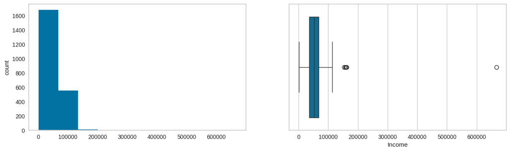

```
Kidhome
```

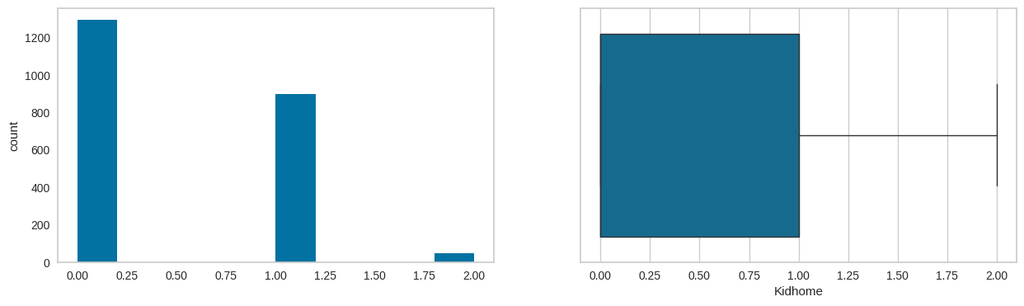

```
Teenhome
```

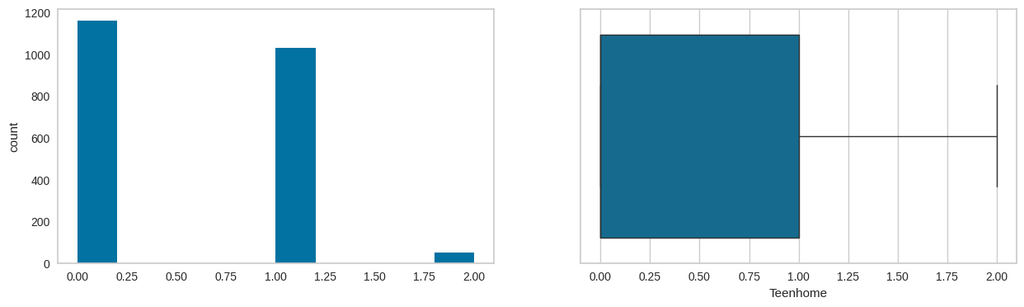

```
Recency
```

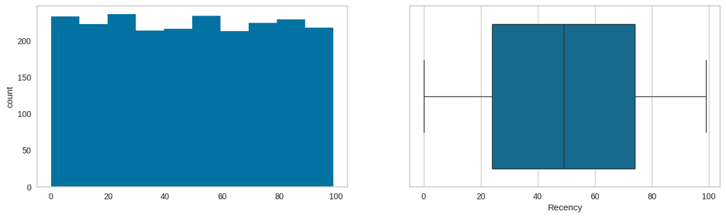

```
MntWines
```

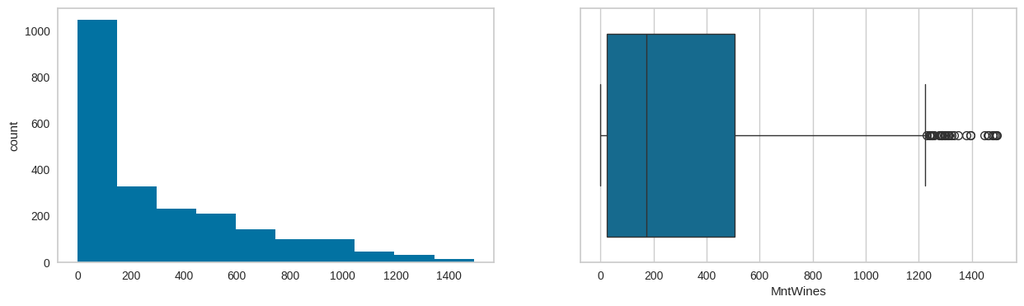

```
MntFruits
```

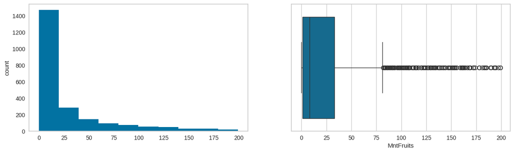

```
MntMeatProducts
```

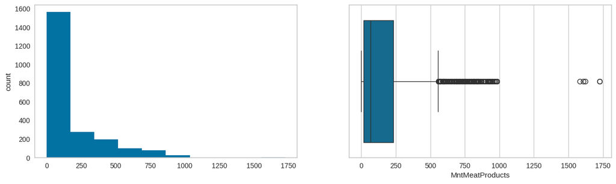

```
MntFishProducts
```

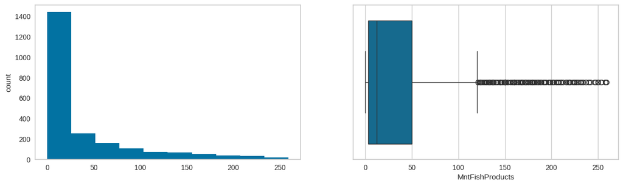

```
MntSweetProducts
```

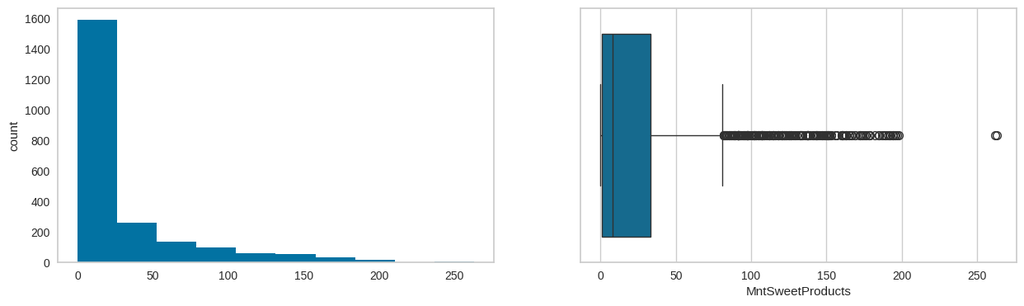

```
MntGoldProds
```

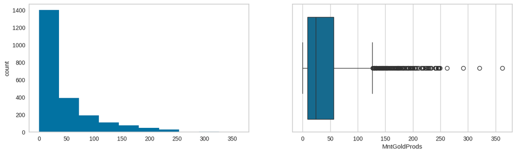

```
NumDealsPurchases
```

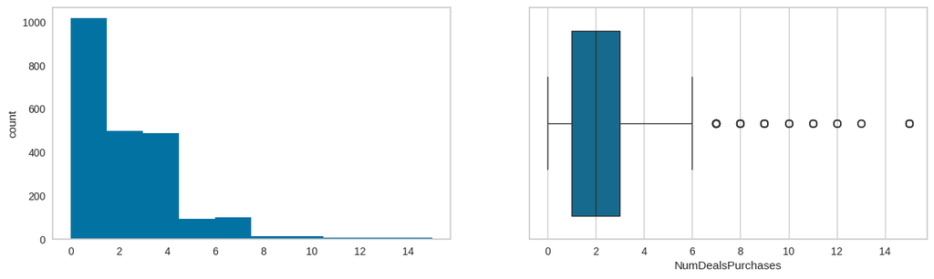

```
NumWebPurchases
```

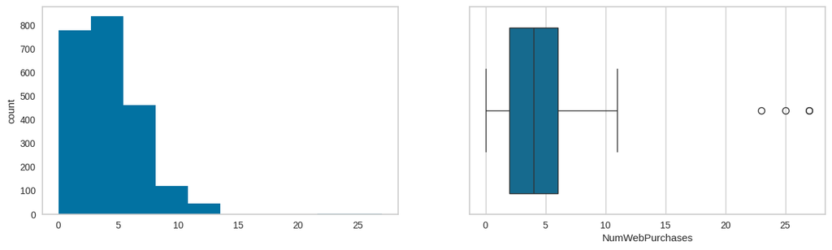

```
NumCatalogPurchases
```

[5 more figures not shown]

```python
# Histogram and Boxplot of all variables

cols = list(df.columns)

for c in cols:
  print(c)
  plt.figure(figsize=(15,4))
  plt.subplot(1,2,1)
  df[c].hist(bins=10, grid=False)
  plt.ylabel('count')
  plt.subplot(1,2,2)
  sns.boxplot(x=df[c])
  plt.show()
```

##### **Observations:**

- Many outliers on the boxplot for these features:
1. MntWine
2. MntFruits
3. MntMeatProducts
4. MntFishProducts
5. MntSweetProducts
6. MntGoldProds
- The distribution is right skewed for these features:
1. Income
2. MntWine
3. MntFruits
4. MntMeatProducts
5. MntFishProducts
6. MntSweetProduct
7. NumDealsPurchases
8. NumCatalogPurchases

### Bivariate Analysis

#### **Question 6:** Perform multivariate analysis to explore the relationsips between the variables.

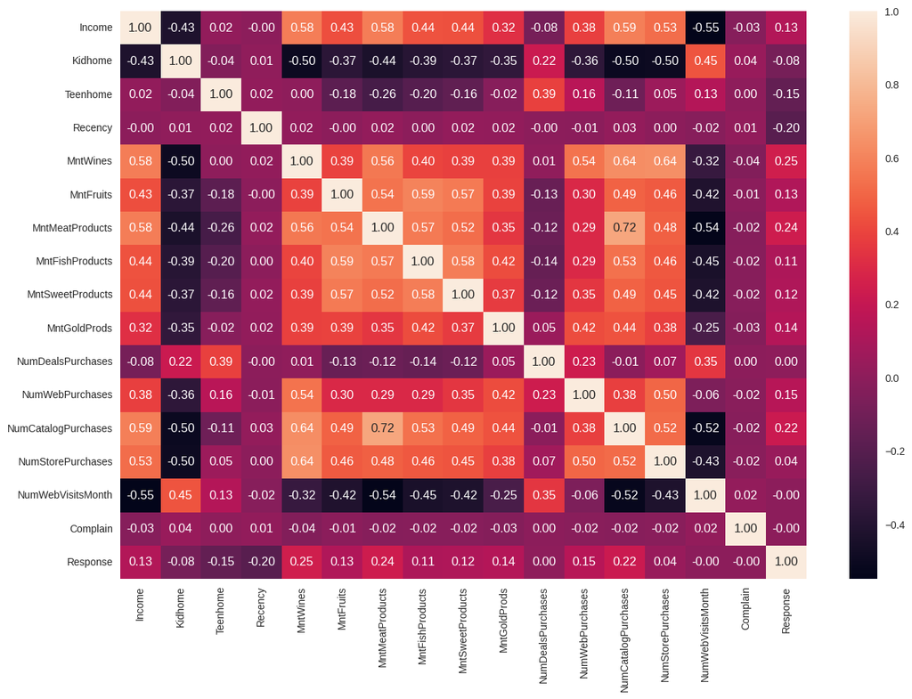

```python
# Checking correlation among the different variables
plt.figure(figsize=(15,10))
sns.heatmap(df.corr(), annot=True,fmt='0.2f')
plt.show()
```

##### **Observations:**

- We can see Positive correlation among the following variables:
1. **Income** with MntWines, MntFruits, MntMeatProducts, MntSweetProducts, MntGoldProds,NumWebPurchases,NumCatalogPurchases,NumStorePurchases
2. All the **Spending Information** (Wine Products, Fruit Products, Meat products, Sweet Products, Gold Products) with eacth other.
3. **Shopping behavior** (Web,In Store, or Catalog) and the **Spending Information** (Wine Products, Fruit Products, Meat products, Sweet Products, Gold Products)
- We can see Negative correlation among the following varibales:
1. **Kidhome** with MntWines, MntFruits, MntMeatProducts, MntSweetProducts, MntGoldProds,NumWebPurchases,NumCatalogPurchases,NumStorePurchases
2. **NumWebVisitMonth** with MntWines, MntFruits, MntMeatProducts, MntSweetProducts,NumCatalogPurchases,NumStorePurchases

## **K-means Clustering**

```python
# Scaling the data
scaler = StandardScaler()
subset = df.copy()
subet_scaled = scaler.fit_transform(subset)
```

```python
# Creating a dataframe of the scaled data

subset_scaled_data = pd.DataFrame(subet_scaled, columns=subset.columns)
```

```python
k_means_data = subset_scaled_data.copy()
```

#### **Question 7** : Select the appropriate number of clusters using the elbow Plot. What do you think is the appropriate number of clusters?

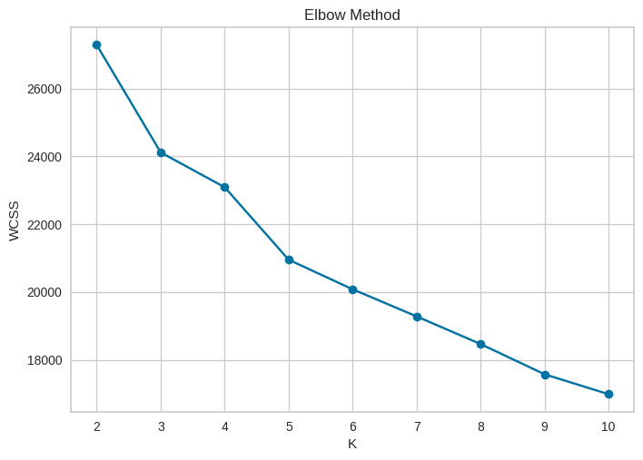

```python
# setting range of number of clusters 2 to 10
cluster = range(2,11)

# Initialize a array to store the SSE for each k
wcss_k =[]

# Iterate for a range of Ks and fit the scaled data to the algorithm.
for k in cluster:
  kmeans = KMeans(n_clusters=k, random_state=1)
  kmeans.fit(subset_scaled_data)
  wcss= kmeans.inertia_
  wcss_k.append(wcss)

# Plot elbow method to find K
plt.plot(cluster, wcss_k, "bx-", marker = 'o')
plt.xlabel("K")
plt.ylabel("WCSS")
plt.title("Elbow Method")
plt.show()
```

##### **Observations:**

The appropriate number of clusters is 3

#### **Question 8** : finalize appropriate number of clusters by checking the silhoutte score as well. Is the answer different from the elbow plot?

```
For k = 2, the silhouette score is 0.3011076105322906
For k = 3, the silhouette score is 0.228927290047533
For k = 4, the silhouette score is 0.21642502206504013
For k = 5, the silhouette score is 0.22772924537517644
For k = 6, the silhouette score is 0.2080204078225739
For k = 7, the silhouette score is 0.12379190183744175
For k = 8, the silhouette score is 0.12067297535500054
For k = 9, the silhouette score is 0.12850219658011203
For k = 10, the silhouette score is 0.14188894247080266
```

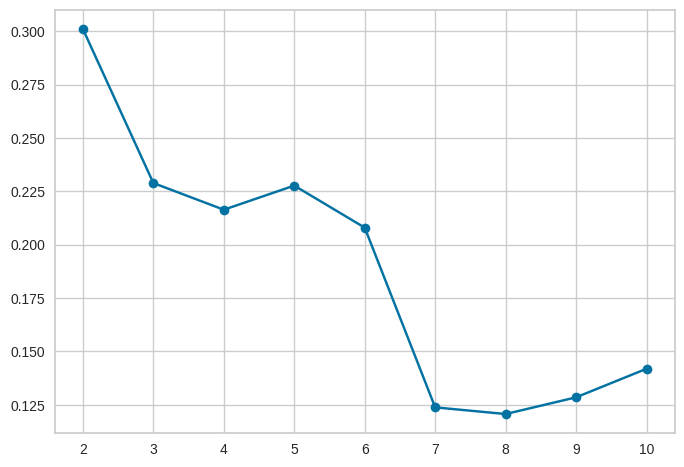

```python
# Array to store the Silhouette score for each value of k
sc=[]

# setting range of number of clusters 2 to 10
cluster = range(2,11)

# iterate for a range of Ks and fit the scaled data to the algorithm. Store the Silhouette score for that k
for k in cluster:
  kmeans = KMeans(n_clusters=k, random_state = 1)
  labels = kmeans.fit_predict(subset_scaled_data)
  score = silhouette_score(subset_scaled_data, labels)
  sc.append(score)
  print("For k = {}, the silhouette score is {}".format(k,score))

#plot Silhouette Score
plt.plot(cluster,sc,marker='o')
plt.show()
```

#### **Question 9**: Do a final fit with the appropriate number of clusters. How much total time does it take for the model to fit the data?

```python
%%time
kmean = KMeans(n_clusters=3, random_state =0)
kmean.fit(k_means_data)
```

```
CPU times: user 9.14 ms, sys: 7.42 ms, total: 16.6 ms
Wall time: 24.4 ms
```

```
KMeans(n_clusters=3, random_state=0)
```

```python
data1 = data.copy()

# adding kmeans cluster labels to the original data and scaled data frames
k_means_data["K_means_segments"]=kmean.labels_
data1["K_means_segments"] = kmean.labels_
```

```python
data1.head()
```

|  | ID | Year_Birth | Education | Marital_Status | Income | Kidhome | Teenhome | Dt_Customer | Recency | MntWines | MntFruits | MntMeatProducts | MntFishProducts | MntSweetProducts | MntGoldProds | NumDealsPurchases | NumWebPurchases | NumCatalogPurchases | NumStorePurchases | NumWebVisitsMonth | AcceptedCmp3 | AcceptedCmp4 | AcceptedCmp5 | AcceptedCmp1 | AcceptedCmp2 | Complain | Z_CostContact | Z_Revenue | Response | … |
| --- | --- | --- | --- | --- | --- | --- | --- | --- | --- | --- | --- | --- | --- | --- | --- | --- | --- | --- | --- | --- | --- | --- | --- | --- | --- | --- | --- | --- | --- | --- |
| 0 | 5524 | 1957 | Graduation | Single | 58138.0 | 0 | 0 | 04-09-2012 | 58 | 635 | 88 | 546 | 172 | 88 | 88 | 3 | 8 | 10 | 4 | 7 | 0 | 0 | 0 | 0 | 0 | 0 | 3 | 11 | 1 | … |
| 1 | 2174 | 1954 | Graduation | Single | 46344.0 | 1 | 1 | 08-03-2014 | 38 | 11 | 1 | 6 | 2 | 1 | 6 | 2 | 1 | 1 | 2 | 5 | 0 | 0 | 0 | 0 | 0 | 0 | 3 | 11 | 0 | … |
| 2 | 4141 | 1965 | Graduation | Together | 71613.0 | 0 | 0 | 21-08-2013 | 26 | 426 | 49 | 127 | 111 | 21 | 42 | 1 | 8 | 2 | 10 | 4 | 0 | 0 | 0 | 0 | 0 | 0 | 3 | 11 | 0 | … |
| 3 | 6182 | 1984 | Graduation | Together | 26646.0 | 1 | 0 | 10-02-2014 | 26 | 11 | 4 | 20 | 10 | 3 | 5 | 2 | 2 | 0 | 4 | 6 | 0 | 0 | 0 | 0 | 0 | 0 | 3 | 11 | 0 | … |
| 4 | 5324 | 1981 | PhD | Married | 58293.0 | 1 | 0 | 19-01-2014 | 94 | 173 | 43 | 118 | 46 | 27 | 15 | 5 | 5 | 3 | 6 | 5 | 0 | 0 | 0 | 0 | 0 | 0 | 3 | 11 | 0 | … |

##### **Observations:**

- Takes the model a total time of 16.6 milliseconds to fit the data

## **Hierarchical Clustering**

```python
# copy of the subset scaled data
hc_data = subset_scaled_data.copy()
```

#### **Question 10**: Calculate the cophnetic correlation for every combination of distance metrics and linkage. Which combination has the highest cophnetic correlation?

```python
# list of distance metric

distance = ["euclidean","chebyshev", "mahalanobis","cityblock"]

#List of linking methods
linkage_m = ["single","complete","average","weighted"]

high_cophenet_corr = 0
high_dm_lm = [0,0]

# Calculating the linkage with the distance metrics and linkage method.
for d in distance:
  for l in linkage_m:
    z=linkage(hc_data,metric=d,method = l)
    c,coph_dists = cophenet(z,pdist(hc_data))
    print("Cophentic correlation for {} distance and {} linkage is {}".format(d.capitalize(),l,c))

    if high_cophenet_corr<c:
      high_cophenet_corr=c
      high_dm_lm[0]=d
      high_dm_lm[1]=l
```

```
Cophentic correlation for Euclidean distance and single linkage is 0.7345070394106017
Cophentic correlation for Euclidean distance and complete linkage is 0.7927934623242414
Cophentic correlation for Euclidean distance and average linkage is 0.8679535206609577
Cophentic correlation for Euclidean distance and weighted linkage is 0.7603395560468081
Cophentic correlation for Chebyshev distance and single linkage is 0.6514642319922342
Cophentic correlation for Chebyshev distance and complete linkage is 0.6818399649220186
Cophentic correlation for Chebyshev distance and average linkage is 0.7764498349866162
Cophentic correlation for Chebyshev distance and weighted linkage is 0.7587791978995797
Cophentic correlation for Mahalanobis distance and single linkage is 0.7646046421857129
Cophentic correlation for Mahalanobis distance and complete linkage is 0.697989867197705
Cophentic correlation for Mahalanobis distance and average linkage is 0.8221860016630311
Cophentic correlation for Mahalanobis distance and weighted linkage is 0.7567720732796923
Cophentic correlation for Cityblock distance and single linkage is 0.8085356679121612
Cophentic correlation for Cityblock distance and complete linkage is 0.5383216932263131
Cophentic correlation for Cityblock distance and average linkage is 0.7910042861496112
Cophentic correlation for Cityblock distance and weighted linkage is 0.7232802634091327
```

```python
# printing the combination of distance metric and linkage method with the highest cophenetic correlation
print("The highest cophentic correlation is {}, which is obtained with {} distance and {} linkage ".format(high_cophenet_corr,high_dm_lm[0],high_dm_lm[1]))
```

```
The highest cophentic correlation is 0.8679535206609577, which is obtained with euclidean distance and average linkage
```

##### **Observations:**

- The highest cophentic correlation is 0.8679535206609577, which is obtained with euclidean distance and average linkage

#### **Question 11**: plot the dendogram for every linkage method with "Euclidean" distance only. What should be the appropriate linkage according to the plot?

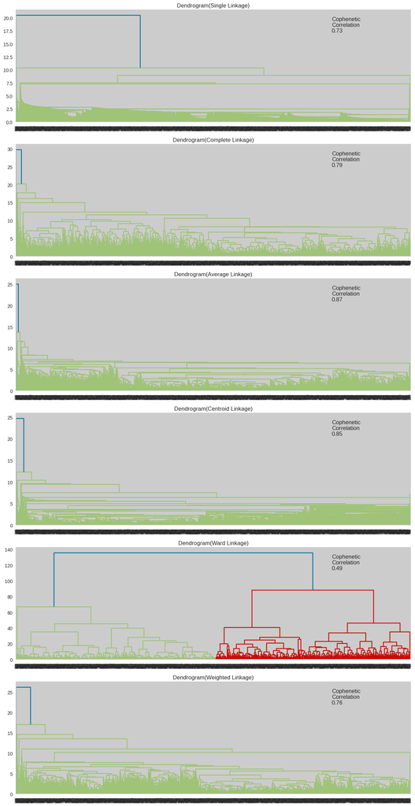

```python
# list of linkage methods
linkage_m = ["single","complete","average", "centroid", "ward","weighted"]

#list to save results of Cophenetic correlation
compare_cols = ["linkage", "Cophenetic Correlation"]
compare = []

#create a plot image
fig, axs = plt.subplots(len(linkage_m), 1, figsize=(15,30))

# For each linkage method, we will plot the dendrogram and calculate the cophenetic correlation
for i, method in enumerate(linkage_m):
  z = linkage(hc_data, metric="euclidean", method=method)
  dendrogram(z,ax=axs[i])

  axs[i].set_title(f"Dendrogram({method.capitalize()} Linkage)")

  coph_corr, coph_dist = cophenet(z,pdist(hc_data))
  axs[i].annotate(f"Cophenetic\nCorrelation\n{coph_corr:0.2f}",(0.80,0.80),xycoords="axes fraction")

  compare.append([method, coph_corr])
```

##### **Observations:**

- The appropriate linkage should be Average Linkage

#### **Question 12:** Check the silhoutte score for the hierchial clustering. What should be the appropriate number of clusters according to this plot?

```python
#Checking silhoutte score for the hierchial clustering

hc_sil_score = []
cluster_list = list(range(2,10))
for n in cluster_list:
  clust=AgglomerativeClustering(n_clusters=n)
  preds = clust.fit_predict((hc_data))
  score = silhouette_score(hc_data,preds)
  hc_sil_score.append(score)
  print("For n={}, silhouette score is {}".format(n,score))
```

```
For n=2, silhouette score is 0.24946445471273893
For n=3, silhouette score is 0.21973356061817814
For n=4, silhouette score is 0.23446540595195547
For n=5, silhouette score is 0.23105592613837297
For n=6, silhouette score is 0.12929865093914
For n=7, silhouette score is 0.13381562820084586
For n=8, silhouette score is 0.15039312893045614
For n=9, silhouette score is 0.13503253954640287
```

#### **Question 13**: Fit the Hierarchial clustering model with the appropriate parameters finalized above. How much time does it take to fit the model?

```python
%%time
HCmodel = AgglomerativeClustering(n_clusters=4,metric="euclidean",linkage="average")
HCmodel.fit(hc_data)
```

```
CPU times: user 187 ms, sys: 19 ms, total: 206 ms
Wall time: 205 ms
```

```
AgglomerativeClustering(linkage='average', n_clusters=4)
```

```python
#creating copy of original data
data2 = data.copy()

# adding hierarchical cluster labels to the original and scaled dataframes
hc_data["HC_segments"] = HCmodel.labels_
data2["HC_segments"] = HCmodel.labels_
```

```python
hc_data.head()
```

|  | Income | Kidhome | Teenhome | Recency | MntWines | MntFruits | MntMeatProducts | MntFishProducts | MntSweetProducts | MntGoldProds | NumDealsPurchases | NumWebPurchases | NumCatalogPurchases | NumStorePurchases | NumWebVisitsMonth | Complain | Response | HC_segments |
| --- | --- | --- | --- | --- | --- | --- | --- | --- | --- | --- | --- | --- | --- | --- | --- | --- | --- | --- |
| 0 | 0.235327 | -0.825218 | -0.929894 | 0.307039 | 0.983781 | 1.551577 | 1.679702 | 2.462147 | 1.476500 | 0.843207 | 0.349414 | 1.409304 | 2.510890 | -0.550785 | 0.693904 | -0.097282 | 2.388846 | 0 |
| 1 | -0.235826 | 1.032559 | 0.906934 | -0.383664 | -0.870479 | -0.636301 | -0.713225 | -0.650449 | -0.631503 | -0.729006 | -0.168236 | -1.110409 | -0.568720 | -1.166125 | -0.130463 | -0.097282 | -0.418612 | 0 |
| 2 | 0.773633 | -0.825218 | -0.929894 | -0.798086 | 0.362723 | 0.570804 | -0.177032 | 1.345274 | -0.146905 | -0.038766 | -0.685887 | 1.409304 | -0.226541 | 1.295237 | -0.542647 | -0.097282 | -0.418612 | 0 |
| 3 | -1.022732 | 1.032559 | -0.929894 | -0.798086 | -0.870479 | -0.560857 | -0.651187 | -0.503974 | -0.583043 | -0.748179 | -0.168236 | -0.750450 | -0.910898 | -0.550785 | 0.281720 | -0.097282 | -0.418612 | 0 |
| 4 | 0.241519 | 1.032559 | -0.929894 | 1.550305 | -0.389085 | 0.419916 | -0.216914 | 0.155164 | -0.001525 | -0.556446 | 1.384715 | 0.329427 | 0.115638 | 0.064556 | -0.130463 | -0.097282 | -0.418612 | 0 |

```python
data2.head()
```

|  | ID | Year_Birth | Education | Marital_Status | Income | Kidhome | Teenhome | Dt_Customer | Recency | MntWines | MntFruits | MntMeatProducts | MntFishProducts | MntSweetProducts | MntGoldProds | NumDealsPurchases | NumWebPurchases | NumCatalogPurchases | NumStorePurchases | NumWebVisitsMonth | AcceptedCmp3 | AcceptedCmp4 | AcceptedCmp5 | AcceptedCmp1 | AcceptedCmp2 | Complain | Z_CostContact | Z_Revenue | Response | … |
| --- | --- | --- | --- | --- | --- | --- | --- | --- | --- | --- | --- | --- | --- | --- | --- | --- | --- | --- | --- | --- | --- | --- | --- | --- | --- | --- | --- | --- | --- | --- |
| 0 | 5524 | 1957 | Graduation | Single | 58138.0 | 0 | 0 | 04-09-2012 | 58 | 635 | 88 | 546 | 172 | 88 | 88 | 3 | 8 | 10 | 4 | 7 | 0 | 0 | 0 | 0 | 0 | 0 | 3 | 11 | 1 | … |
| 1 | 2174 | 1954 | Graduation | Single | 46344.0 | 1 | 1 | 08-03-2014 | 38 | 11 | 1 | 6 | 2 | 1 | 6 | 2 | 1 | 1 | 2 | 5 | 0 | 0 | 0 | 0 | 0 | 0 | 3 | 11 | 0 | … |
| 2 | 4141 | 1965 | Graduation | Together | 71613.0 | 0 | 0 | 21-08-2013 | 26 | 426 | 49 | 127 | 111 | 21 | 42 | 1 | 8 | 2 | 10 | 4 | 0 | 0 | 0 | 0 | 0 | 0 | 3 | 11 | 0 | … |
| 3 | 6182 | 1984 | Graduation | Together | 26646.0 | 1 | 0 | 10-02-2014 | 26 | 11 | 4 | 20 | 10 | 3 | 5 | 2 | 2 | 0 | 4 | 6 | 0 | 0 | 0 | 0 | 0 | 0 | 3 | 11 | 0 | … |
| 4 | 5324 | 1981 | PhD | Married | 58293.0 | 1 | 0 | 19-01-2014 | 94 | 173 | 43 | 118 | 46 | 27 | 15 | 5 | 5 | 3 | 6 | 5 | 0 | 0 | 0 | 0 | 0 | 0 | 3 | 11 | 0 | … |

```python
subset_scaled_data["HC_Clusters"] = HCmodel.labels_
data["HC_Clusters"] = HCmodel.labels_
```

##### **Observations:**

- It take 206 milliseconds to fit the model

## **Cluster Profiling and Comparison**

### K-Means Clustering vs Hierarchical Clustering Comparison

#### **Question 14**: Perform and compare Cluster profiling on both algorithms using boxplots. Based on the all the observaions Which one of them provides better clustering?

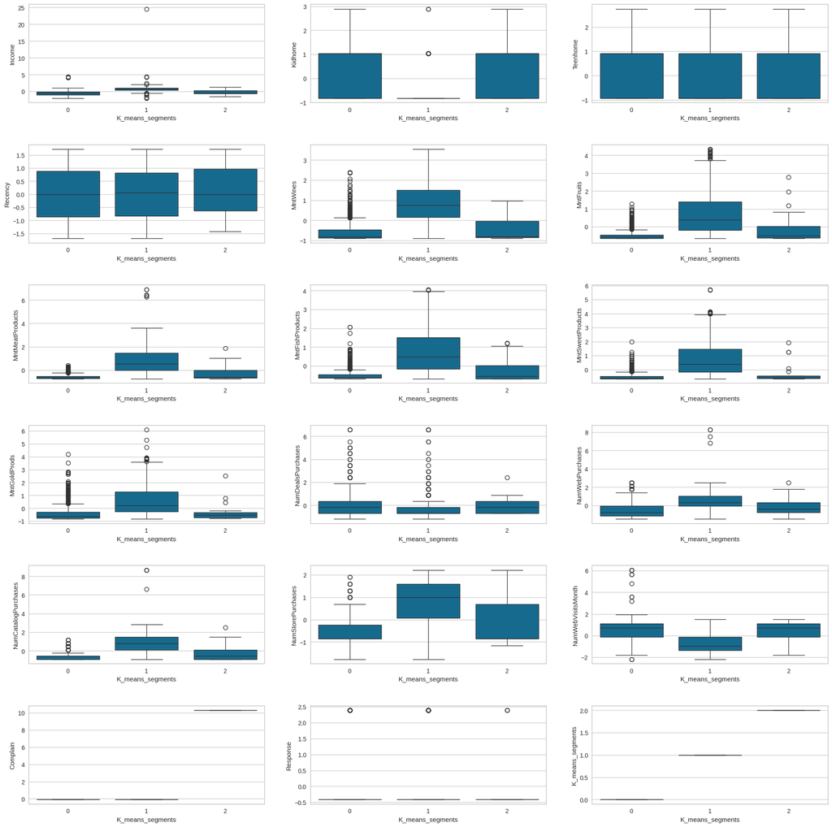

```python
fig, axes = plt.subplots(6, 3, figsize = (20, 20))
counter = 0

for i in range(6):
    for j in range(3):
        if counter < 19:
            sns.boxplot(
                ax = axes[i][j],
                data = k_means_data,
                y = k_means_data.columns[counter],
                x = "K_means_segments",
            )
            counter = counter + 1

fig.tight_layout(pad = 3.0)
```

##### **Observations:**

- **Cluster 0**
1. Have both teen and kid in their home
2. Use deals to buy our products
3. Doesn't really make any pruchases
4. Visit our website multiple times a month
- **Cluster 1**
  1. Have teens in their home
  2. buys a large amount of our products
  3. Commonly makes both in store and catalog purchses
  4. Doesn't really visit the website
- **Cluster 2**
  1. Have both teen and kid in their home
  2. Use deals to buy our products
  3. Does in store purchases mostly
  4. Visit our website multiple times a month

#### **Question 15**: Perform Cluster profiling on the data with the appropriate algorithm determined above using a barplot. What observations can be derived for each cluster from this plot?

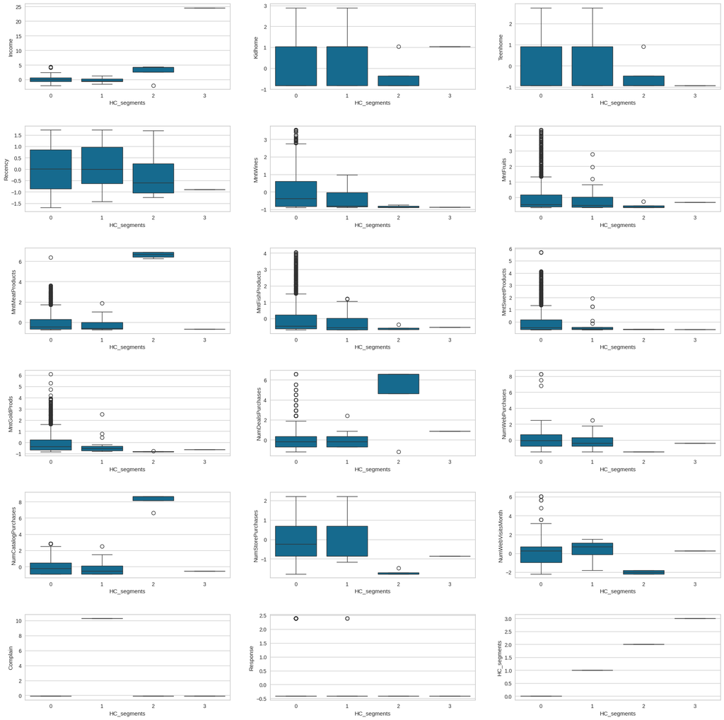

```python
fig, axes = plt.subplots(6, 3, figsize = (20, 20))
counter = 0

for i in range(6):
    for j in range(3):
        if counter < 19:
            sns.boxplot(
                ax = axes[i][j],
                data = hc_data,
                y = hc_data.columns[counter],
                x = "HC_segments",
            )
            counter = counter + 1

fig.tight_layout(pad = 3.0)
```

##### **Observations:**

- **Cluster 0**
  1. Has both Teen and Kid in their home
  2. Does mostly in store purchases
  3. Buys mostly wine
- **Cluster 1**
  1. Does deals purchases
  2. Does mostly in store purchases
  3. mostly visit website multiple time
- **Cluster 2**
  1. Purchase most products from the catalog
  2. Does many deal purchases
  3. Buys mostly of meat products
- **Cluster 3**
  1. Mostly do deal purchases
  2. Visit website multiple times
  3. Does some in store purchases

## **Business Recommedations**

- **Incentivize Higher Engagement**: Offer targeted discounts or special offers to encourage increased spending and purchases across channels.
- **Educate About Products**: Provide content (emails, guides, or social media) showcasing the value and uniqueness of products they don’t purchase frequently.
- **Improve Campaign Effectiveness**: Refine campaign messaging based on their moderate response rate to increase acceptance.

- **Win-Back Campaigns**: Implement campaigns specifically aimed at bringing back inactive customers, such as offering steep discounts or limited-time offers.
- **Understand Barriers to Engagement**: Conduct surveys or collect feedback to identify reasons for their low purchases and disengagement.
- **Promote Entry-Level Products**: Introduce affordable or trial-sized products to ease them into higher spending.

### **4. Convert Browsers into Buyers (Cluster 0)**

- **Optimize Website Experience**: Since Cluster 0 has high website visits but low spending, improve website navigation, showcase popular products, and streamline the checkout process.
- **Targeted Digital Campaigns**: Retarget these users with ads or emails featuring products they browsed but didn’t purchase.
- **Offer Online-Exclusive Discounts**: Provide web-only discounts or promotions to convert visits into purchases.

### **7. Leverage Product-Specific Insights**

- Promote popular categories (e.g., wines, gold products) to high-value clusters, while running introductory campaigns for less-engaged clusters to familiarize them with premium products.

By focusing on these strategies, the company can enhance engagement, increase revenue, and strengthen customer loyalty across all clusters.